# What genes are differentially expressed between technologies?

J. Taroni for CCDL

2019

We’ll use `limma` to identify genes that are differentially expressed between microarray and RNA-seq samples in the test compendium.

Note that I had to roll back the R version here to get `Rsamtools` to install. This will be captured by `sessionInfo()` below.

## Set up

```r
`%>%` <- dplyr::`%>%`
```

```r
library(limma)
library(GenomicRanges)
library(rtracklayer)
library(Rsamtools)
```

```r
results_dir <- "results"
dir.create(results_dir, showWarnings = FALSE)
```

## Read in data

Test compendium expression matrix

```r
exprs_mat_file <- file.path("data", "larger_compendium_exprs_mat.RDS")
exprs_mat <- readRDS(exprs_mat_file)
```

Generate technology labels using the sample names

```r
sample_names <- colnames(exprs_mat)
compendium_technology_labels <- rep("MICROARRAY", length(sample_names))
compendium_technology_labels[grep("SRR|ERR|DRR", sample_names)] <- "RNASEQ"
```

## Differential expression

Test for genes that are differentially expressed between technologies

```r
design_matrix <- model.matrix(~ compendium_technology_labels)
fit <- lmFit(exprs_mat, design = design_matrix)
fit2 <- eBayes(fit)
diff_exp_stats <- topTable(fit2, number = nrow(exprs_mat)) %>%
  as.data.frame() %>%
  tibble::rownames_to_column("Gene")
```

```
Removing intercept from test coefficients
```

Save to file

```r
readr::write_tsv(diff_exp_stats,
                 file.path(results_dir,
                           "larger_compendium_diff_exprs_technologies.tsv"))
```

Let’s take a peak at the “top” differentially expressed genes.

```r
diff_exp_stats %>%
  dplyr::filter(adj.P.Val < 0.00001) %>%
  dplyr::arrange(`t`) %>%
  head()
```

|  | Gene | logFC | AveExpr | t | P.Value | adj.P.Val | B |
| --- | --- | --- | --- | --- | --- | --- | --- |
| 1 | ENSDARG00000098608 | -1.700259 | 0.26307205 | -234.7375 | 0 | 0 | 11000.664 |
| 2 | ENSDARG00000074720 | -1.022235 | 0.02465116 | -223.0457 | 0 | 0 | 10449.462 |
| 3 | ENSDARG00000061547 | -3.317263 | 0.65894136 | -219.0799 | 0 | 0 | 10258.713 |
| 4 | ENSDARG00000061728 | -1.339663 | 0.16429325 | -215.3272 | 0 | 0 | 10076.424 |
| 5 | ENSDARG00000040556 | -1.907321 | 0.29454687 | -214.4465 | 0 | 0 | 10033.390 |
| 6 | ENSDARG00000086996 | -1.684666 | 0.21980093 | -199.2862 | 0 | 0 | 9277.485 |

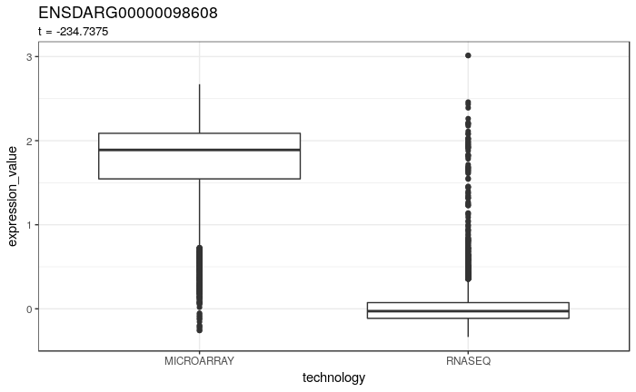

```r
data.frame(
  expression_value = exprs_mat["ENSDARG00000098608", ],
  technology = compendium_technology_labels
) %>%
  ggplot2::ggplot(ggplot2::aes(x = technology, y = expression_value)) +
  ggplot2::geom_boxplot() +
  ggplot2::labs(title = "ENSDARG00000098608", subtitle = "t = -234.7375") +
  ggplot2::theme_bw()
```

Genes with negative `t` values have lower values in RNA-seq samples.

Let’s take a look at the genes that have higher values in RNA-seq samples (positive `t`).

```r
diff_exp_stats %>%
  dplyr::filter(adj.P.Val < 0.00001) %>%
  dplyr::arrange(`t`) %>%
  tail()
```

|  | Gene | logFC | AveExpr | t | P.Value | adj.P.Val | B |
| --- | --- | --- | --- | --- | --- | --- | --- |
| 13001 | ENSDARG00000025789 | 2.024507 | 2.580329 | 137.0695 | 0 | 0 | 5889.727 |
| 13002 | ENSDARG00000099675 | 1.315379 | 1.410879 | 144.0851 | 0 | 0 | 6291.580 |
| 13003 | ENSDARG00000045401 | 1.499515 | 1.333926 | 148.9128 | 0 | 0 | 6565.795 |
| 13004 | ENSDARG00000054290 | 2.988747 | 3.166173 | 149.2304 | 0 | 0 | 6583.759 |
| 13005 | ENSDARG00000035285 | 1.917222 | 1.818350 | 162.3155 | 0 | 0 | 7315.422 |
| 13006 | ENSDARG00000060767 | 1.556474 | 1.535973 | 165.2244 | 0 | 0 | 7475.633 |

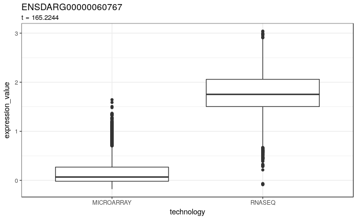

```r
data.frame(
  expression_value = exprs_mat["ENSDARG00000060767", ],
  technology = compendium_technology_labels
) %>%
  ggplot2::ggplot(ggplot2::aes(x = technology, y = expression_value)) +
  ggplot2::geom_boxplot() +
  ggplot2::labs(title = "ENSDARG00000060767", subtitle = "t = 165.2244") +
  ggplot2::theme_bw()
```

### Relationship with gene lengths?

Is there any relationship between the length of a gene and its `t` statistic?

`GRCz11` related files were obtained in `00-data_download.sh`

Adapted from: https://github.com/dpryan79/Answers/blob/d2d7366fec907fd92ccf03e77c2d53cfe45b02c9/SEQanswers_42420/GTF2LengthGC.R

See also: https://bioinformatics.stackexchange.com/questions/2567/how-can-i-calculate-gene-length-for-rpkm-calculation-from-counts-data

Non-duplicated exons from each gene are summed up to get the length (“union gene model”).

```r
# obtained in 00-data_download.sh
gtf_file <- file.path("data", "GRCz11", "Danio_rerio.GRCz11.95.gtf")
# Load the annotation and reduce it -- filtering for exons
gtf <- import.gff(gtf_file, format = "gtf", genome = "GRCz11.95",
                  feature.type = "exon")
grl <- reduce(split(gtf, elementMetadata(gtf)$gene_id))
reduced_gtf <- unlist(grl, use.names = TRUE)
elementMetadata(reduced_gtf)$gene_id <- rep(names(grl), elementNROWS(grl))
# add the widths to the metadata slot -- number of values in the range
elementMetadata(reduced_gtf)$widths <- width(reduced_gtf)
output <- t(sapply(
  split(reduced_gtf, elementMetadata(reduced_gtf)$gene_id),
  # for each gene sum exon widths
  function(x) sum(elementMetadata(x)$widths)))
output[, 1:5]
```

```
ENSDARG00000000001 ENSDARG00000000002 ENSDARG00000000018 ENSDARG00000000019 ENSDARG00000000068
              2476               2604               3013               2758               2397
```

```r
gene_lengths_df <- data.frame(Gene = colnames(output),
                              gene_length = output[1, ])
readr::write_tsv(gene_lengths_df,
                 file.path("data",
                           "Danio_rerio.GRCz11_gene_lengths_exons.tsv"))
```

```r
# if one already had the gene lengths file, it could be loaded:
# gene_lengths_df <-
#   readr::read_tsv(file.path("data",
#                             "Danio_rerio.GRCz11_gene_names_and_lengths.tsv"),
#                   col_names = FALSE) %>%
#   dplyr::mutate(X1 = sub("gene:", "", X1))
```

Join the t-statistic with the gene lengths and make a scatterplot

```
Column `Gene` joining character vector and factor, coercing into character vector
```

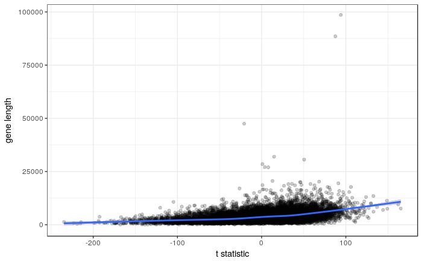

```r
dplyr::inner_join(diff_exp_stats, gene_lengths_df,
                  by = "Gene") %>%
  dplyr::select(c("Gene", "t", "gene_length")) %>%
  ggplot2::ggplot(ggplot2::aes(x = `t`, y = gene_length)) +
  ggplot2::geom_point(alpha = 0.2) +
  ggplot2::geom_smooth() +
  ggplot2::theme_bw() +
  ggplot2::labs(x = "t statistic", y = "gene length")
```

As noted above:

> Genes with negative `t` values have lower values in RNA-seq samples.

So longer genes tend to have higher expression values in RNA-seq data.

```r
scatter_file <- file.path("plots", "larger_compendium_tstat_length_scatter.png")
ggplot2::ggsave(filename = scatter_file,
                plot = ggplot2::last_plot())
```

[session information not shown]